# EDA Swire Coca Cola

### Final Check for Missing Values

```r
# Check for missing values after imputation
missing_after_imputation <- sapply(data, function(x) sum(is.na(x)))
print(missing_after_imputation)
```

```
                       ORDER_ID                        PLANT_ID
                              0                               0
            PRODUCTION_LOCATION            EXECUTION_START_DATE
                              0                               0
          EXECUTION_FINISH_DATE               ACTUAL_START_TIME
                              0                               0
             ACTUAL_FINISH_TIME          ACTUAL_WORK_IN_MINUTES
                              0                               0
               MAINTENANCE_PLAN                MAINTENANCE_ITEM
                              0                         1274670
      MAINTENANCE_ACTIVITY_TYPE               ORDER_DESCRIPTION
                              0                               0
   MAINTENANCE_TYPE_DESCRIPTION                  FUNCTIONAL_LOC
                              0                               0
FUNCTIONAL_AREA_NODE_1_MODIFIED FUNCTIONAL_AREA_NODE_2_MODIFIED
                              0                         1144857
FUNCTIONAL_AREA_NODE_3_MODIFIED FUNCTIONAL_AREA_NODE_4_MODIFIED
                        1168573                         1189691
FUNCTIONAL_AREA_NODE_5_MODIFIED                    EQUIPMENT_ID
                        1425084                         1135469
                 EQUIPMENT_DESC                  EQUIP_CAT_DESC
                              0                               0
            EQUIP_START_UP_DATE                EQUIP_VALID_FROM
                        1347817                         1347817
                 EQUIP_VALID_TO
                        1347817
```

### Visual Verification- After Imputation Visualization

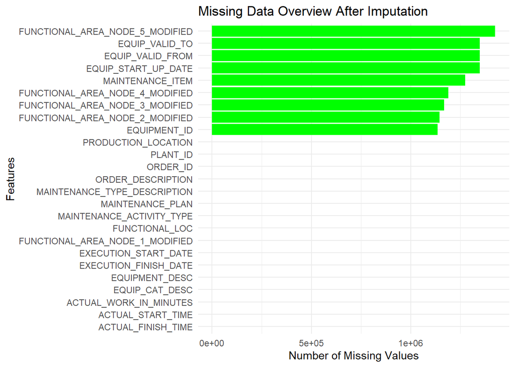

```r
# Visualize missing data after handling
missing_data_after <- data.frame(Feature = names(data), MissingCount = sapply(data, function(x) sum(is.na(x))))
ggplot(missing_data_after, aes(x=reorder(Feature, MissingCount), y=MissingCount)) +
  geom_bar(stat='identity', fill='green') +
  coord_flip() +
  labs(title='Missing Data Overview After Imputation', x='Features', y='Number of Missing Values') +
  theme_minimal()
```

The graphs shows few columns that have not been imputed for the missing values because of the limitation of handing them through statistical imputation. Other columns like maintenance plan, order description are being handled.

### Summary Statistics Check

```r
# Summary statistics after handling missing values
summary(data)
```

```
    ORDER_ID           PLANT_ID         PRODUCTION_LOCATION
 Min.   :1.000e+08   Length:1427264     Length:1427264
 1st Qu.:4.023e+08   Class :character   Class :character
 Median :7.044e+08   Mode  :character   Mode  :character
 Mean   :4.561e+10
 3rd Qu.:1.002e+09
 Max.   :9.000e+11

 EXECUTION_START_DATE EXECUTION_FINISH_DATE ACTUAL_START_TIME
 Length:1427264       Length:1427264        Length:1427264
 Class :character     Class :character      Class :character
 Mode  :character     Mode  :character      Mode  :character




 ACTUAL_FINISH_TIME ACTUAL_WORK_IN_MINUTES MAINTENANCE_PLAN   MAINTENANCE_ITEM
 Length:1427264     Min.   :     0.0       Length:1427264     Min.   : 39801
 Class :character   1st Qu.:    12.0       Class :character   1st Qu.: 41046
 Mode  :character   Median :    48.0       Mode  :character   Median :112995
                    Mean   :    88.6                          Mean   :115847
                    3rd Qu.:    90.0                          3rd Qu.:134702
                    Max.   :330184.8                          Max.   :346352
                                                              NA's   :1274670
 MAINTENANCE_ACTIVITY_TYPE ORDER_DESCRIPTION  MAINTENANCE_TYPE_DESCRIPTION
 Length:1427264            Length:1427264     Length:1427264
 Class :character          Class :character   Class :character
 Mode  :character          Mode  :character   Mode  :character




 FUNCTIONAL_LOC     FUNCTIONAL_AREA_NODE_1_MODIFIED
 Length:1427264     Length:1427264
 Class :character   Class :character
 Mode  :character   Mode  :character




```

[output cut: 13 more lines]

```



  EQUIPMENT_ID       EQUIPMENT_DESC     EQUIP_CAT_DESC     EQUIP_START_UP_DATE
 Min.   :200087110   Length:1427264     Length:1427264     Length:1427264
 1st Qu.:300009161   Class :character   Class :character   Class :character
 Median :300017751   Mode  :character   Mode  :character   Mode  :character
 Mean   :300260910
 3rd Qu.:300026939
 Max.   :400029000
 NA's   :1135469
 EQUIP_VALID_FROM   EQUIP_VALID_TO
 Length:1427264     Length:1427264
 Class :character   Class :character
 Mode  :character   Mode  :character
```

## General Exploration of the Dataset

### **What are the trends in machine downtimes over time?**

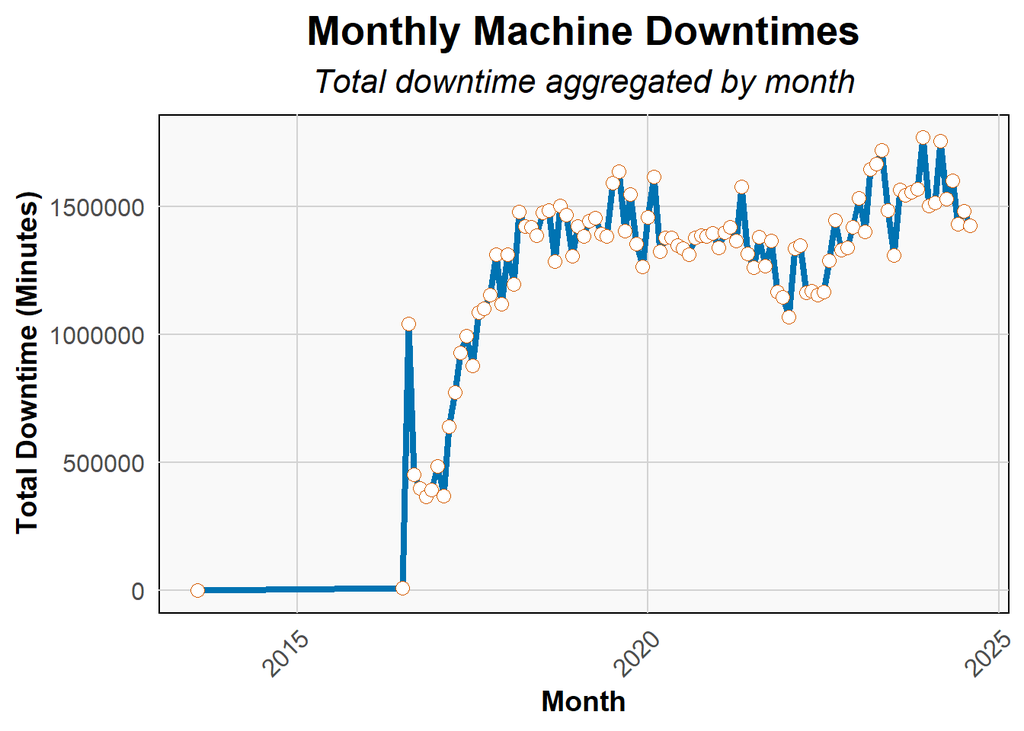

```r
# Convert dates
data$EXECUTION_START_DATE <- as.Date(data$EXECUTION_START_DATE)

# Aggregate downtime by month
monthly_downtime <- data %>%
  group_by(month = floor_date(EXECUTION_START_DATE, "month")) %>%
  summarise(total_downtime = sum(ACTUAL_WORK_IN_MINUTES, na.rm = TRUE), .groups = "drop")  # Handle NAs and drop groups

# Plotting the trend with enhanced aesthetics
ggplot(monthly_downtime, aes(x = month, y = total_downtime)) +
  geom_line(color = "#0073B2", size = 1.5) +  # Use a custom blue color with increased line size
  geom_point(color = "#D55E00", size = 3, shape = 21, fill = "white") +  # Custom points with fill color
  labs(
    title = "Monthly Machine Downtimes",
    subtitle = "Total downtime aggregated by month",
    x = "Month",
    y = "Total Downtime (Minutes)"
  ) +
  theme_minimal(base_size = 15) +  # Increase base font size
  theme(
    plot.title = element_text(hjust = 0.5, size = 20, face = "bold"),  # Center title and make it bold
    plot.subtitle = element_text(hjust = 0.5, size = 16, face = "italic"),  # Center subtitle and italicize
    axis.title.x = element_text(size = 14, face = "bold"),  # Bold x-axis title
    axis.title.y = element_text(size = 14, face = "bold"),  # Bold y-axis title
    axis.text.x = element_text(angle = 45, hjust = 1),  # Rotate x-axis labels for better visibility
    panel.grid.major = element_line(color = "#D3D3D3", size = 0.5),  # Major grid lines color
    panel.grid.minor = element_blank(),  # Remove minor grid lines
    panel.background = element_rect(fill = "#F9F9F9")  # Light background for better contrast
  )
```

The graph indicates that machine downtime became a significant issue around 2016, and since then, there have been consistently high levels of downtime. This could be a reflection of recurring maintenance problems or breakdowns that have not been effectively addressed. The regular spikes suggest that downtimes may correlate with specific events or maintenance schedules. This pattern highlights the potential need for improved predictive maintenance strategies to minimize these recurring spikes in machine downtime.